# Reproducible Research: Peer Assessment 1

## Loading and preprocessing the data

##### 1. Installing and loading requisite libraries if they don’t already exist

```r
if (!("ggplot2" %in% rownames(installed.packages())) ) {
  install.packages("ggplot2")
} else {
  library(ggplot2)
}

if (!("scales" %in% rownames(installed.packages())) ) {
  install.packages("scales")
} else {
  library(scales)
}

if (!("Hmisc" %in% rownames(installed.packages())) ) {
  install.packages("Hmisc")
} else {
  library(Hmisc)
}
```

##### 2. Unzipping, then loading the given activity data using read.csv().

```r
if(!file.exists('activity.csv')){
    unzip('activity.zip')
}
given_activity_data <- read.csv('activity.csv')
```

## What is mean total number of steps taken per day?

##### 1. Summing up the number of steps taken per day

```r
sum_of_steps_per_day <- tapply(given_activity_data$steps, given_activity_data$date, sum, na.rm=TRUE)
```

##### 2. Making a histogram of the total number of steps taken each day

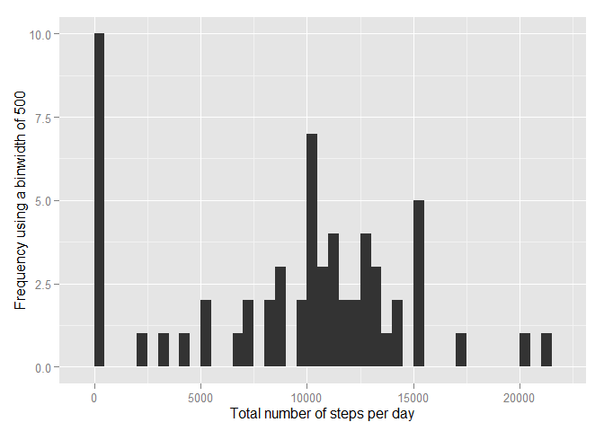

```r
qplot(sum_of_steps_per_day, xlab='Total number of steps per day', ylab='Frequency using a binwidth of 500', binwidth=500)
```

##### 3. Computing the mean and median of the total number of steps taken per day

```r
mean_of_steps_per_day <- mean(sum_of_steps_per_day)
median_of_steps_per_day <- median(sum_of_steps_per_day)
```

- Mean: 9354.2295082
- Median: 10395

## What is the average daily activity pattern?

```r
average_steps_per_timeblock <- aggregate(x=list(mean_of_steps=given_activity_data$steps), by=list(interval=given_activity_data$interval), FUN=mean, na.rm=TRUE)
```

##### 1. Making a time series plot

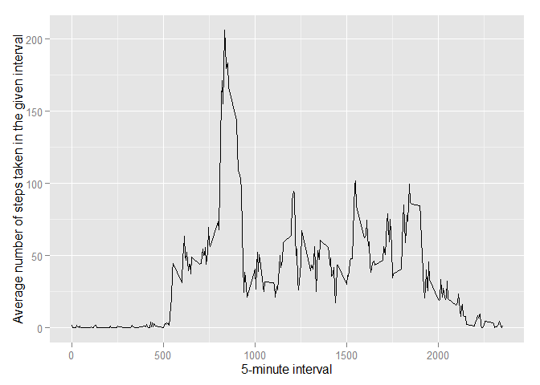

```r
ggplot(data=average_steps_per_timeblock, aes(x=interval, y=mean_of_steps)) +
    geom_line() +
    xlab("5-minute interval") +
    ylab("Average number of steps taken in the given interval")
```

##### 2. Figuring out which 5-minute interval, on average across all the days in the dataset, contains the maximum number of steps

```r
most_steps <- which.max(average_steps_per_timeblock$mean_of_steps)
time_at_most_steps <-  gsub("([0-9]{1,2})([0-9]{2})", "\\1:\\2", average_steps_per_timeblock[most_steps,'interval'])
```

- Most Steps at: 8:35

## Imputing missing values

##### 1. Computing the total number of missing values in the dataset

```r
number_of_missing_values <- length(which(is.na(given_activity_data$steps)))
```

- Number of missing values: 2304

##### 2. Devising a strategy for filling in all of the missing values in the dataset.

```r
imputed_activity_data <- given_activity_data
imputed_activity_data$steps <- impute(given_activity_data$steps, FUN=mean)
```

##### 4. Making a histogram of the total number of steps taken each day

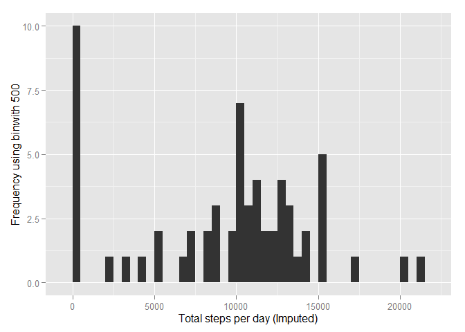

```r
steps_by_day_after_data_imputation <- tapply(imputed_activity_data$steps, imputed_activity_data$date, sum)
qplot(steps_by_day_after_data_imputation, xlab='Total steps per day (Imputed)', ylab='Frequency using binwith 500', binwidth=500)
```

##### 5. Calculating the mean and median total number of steps taken per day using imputed data

```r
mean_steps_by_day_after_data_imputation <- mean(steps_by_day_after_data_imputation)
median_steps_by_day_after_data_imputation <- median(steps_by_day_after_data_imputation)
```

[output not shown]

## Are there differences in activity patterns between weekdays and weekends?

##### 1. Creating a new factor variable in the dataset for “weekday” and “weekend”

```r
imputed_activity_data$dateType <-  ifelse(as.POSIXlt(imputed_activity_data$date)$wday %in% c(0,6), 'weekend', 'weekday')
```

##### 2. Plotting time series using a panel plot

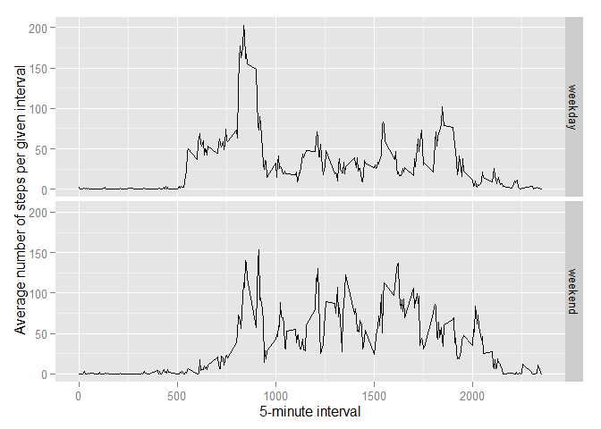

```r
averaged_imputed_data <- aggregate(steps ~ interval + dateType, data=imputed_activity_data, mean)
ggplot(averaged_imputed_data, aes(interval, steps)) +
    geom_line() +
    facet_grid(dateType ~ .) +
    xlab("5-minute interval") +
    ylab("Average number of steps per given interval")
```